# plotly

# Modifying Matplotlib Figure in matplotlib

How to modify a matplotlib figure to a Plotly Figure

# Modifying a Matplotlib Figure

In this example, we will see how we can convert a Matplotlib's Plot to a Plotly Compatible `Figure` object.

Importing the dependencies:

```python
%matplotlib inline
import pprint
import numpy as np

# Matplotlib
import matplotlib.pyplot as plt

# Plotly
import plotly.plotly as py
import plotly.tools as tls
```

We will create a simple sine curve using Matplotlib. Then, we will convert it into Plotly's Figure object, and add another curve to the plot. Finally we will be able to plot the curve using Plotly.

```python
## Generating the data..
x =  np.linspace(np.pi, 3*np.pi, 1000)
sinx = np.sin(x)
logx = np.log(x)
```

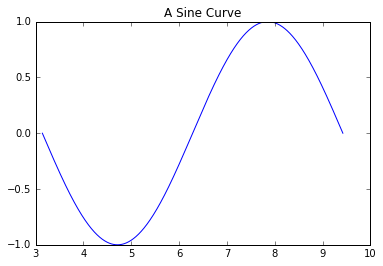

```python
# Creating the matplotlib graph..
mpl_fig = plt.figure()
ax = mpl_fig.add_subplot(111)
ax.plot(x, sinx)
ax.set_title('A Sine Curve')
```

Now we will convert the figure into Plotly compatible figure object using a utility method `mpl_to_plotly`.

```python
help (tls.mpl_to_plotly)
```

```
Help on function mpl_to_plotly in module plotly.tools:

mpl_to_plotly(fig, resize=False, strip_style=False, verbose=False)
    Convert a matplotlib figure to plotly dictionary and send.

    All available information about matplotlib visualizations are stored
    within a matplotlib.figure.Figure object. You can create a plot in python
    using matplotlib, store the figure object, and then pass this object to
    the fig_to_plotly function. In the background, mplexporter is used to
    crawl through the mpl figure object for appropriate information. This
    information is then systematically sent to the PlotlyRenderer which
    creates the JSON structure used to make plotly visualizations. Finally,
    these dictionaries are sent to plotly and your browser should open up a
    new tab for viewing! Optionally, if you're working in IPython, you can
    set notebook=True and the PlotlyRenderer will call plotly.iplot instead
    of plotly.plot to have the graph appear directly in the IPython notebook.

    Note, this function gives the user access to a simple, one-line way to
    render an mpl figure in plotly. If you need to trouble shoot, you can do
    this step manually by NOT running this fuction and entereing the following:

    ===========================================================================
    from mplexporter import Exporter
    from mplexporter.renderers import PlotlyRenderer

    # create an mpl figure and store it under a varialble 'fig'

    renderer = PlotlyRenderer()
    exporter = Exporter(renderer)
    exporter.run(fig)
    ===========================================================================

    You can then inspect the JSON structures by accessing these:

    renderer.layout -- a plotly layout dictionary
    renderer.data -- a list of plotly data dictionaries

    Positional arguments:
    fig -- a matplotlib figure object
    username -- a valid plotly username **
    api_key -- a valid api_key for the above username **
    notebook -- an option for use with an IPython notebook

    ** Don't have a username/api_key? Try looking here:
    https://plot.ly/plot

    ** Forgot your api_key? Try signing in and looking here:
    https://plot.ly/python/getting-started
```

```python
# Converting to Plotly's Figure object..
plotly_fig = tls.mpl_to_plotly(mpl_fig)
```

```python
pp = pprint.PrettyPrinter(indent=4)
pp.pprint(plotly_fig['layout'])
```

```
{   'autosize': False,
    'height': 320,
    'hovermode': 'closest',
    'margin': {   'b': 40, 'l': 60, 'pad': 0, 'r': 47, 't': 31},
    'showlegend': False,
    'title': u'A Sine Curve',
    'titlefont': {   'color': '#000000', 'size': 12.0},
    'width': 480,
    'xaxis1': {   'anchor': 'y1',
                  'domain': [0.0, 1.0],
                  'mirror': 'ticks',
                  'nticks': 8,
                  'range': [3.0, 10.0],
                  'showgrid': False,
                  'showline': True,
                  'side': 'bottom',
                  'tickfont': {   'size': 10.0},
                  'ticks': 'inside',
                  'type': u'linear',
                  'zeroline': False},
    'yaxis1': {   'anchor': 'x1',
                  'domain': [0.0, 1.0],
                  'mirror': 'ticks',
                  'nticks': 5,
                  'range': [-1.0, 1.0],
                  'showgrid': False,
                  'showline': True,
                  'side': 'left',
                  'tickfont': {   'size': 10.0},
                  'ticks': 'inside',
                  'type': u'linear',
                  'zeroline': False}}
```

Now, we will supply some data to `plotly_fig`:

```python
# Adding some new data points ..
plotly_fig['data'].append( dict(x=x, y=logx, type='scatter', mode='lines') )
```

Similarly, we can also edit the `Layout`. We will edit the Plot Title, and enable the grid here:

```python
plotly_fig['layout']['title'] = 'Sine and Logarithmic Curve'

plotly_fig['layout']['xaxis1']['showgrid'] = True
plotly_fig['layout']['xaxis1']['autorange'] = True

plotly_fig['layout']['yaxis1']['showgrid'] = True
plotly_fig['layout']['yaxis1']['autorange'] = True
```

Now we can plot the modified figure using Plotly's Graphing API:

```python
py.iplot(plotly_fig, filename='sine-and-logarithmic-plot')
```

[interactive chart not shown]